# main

### Dataset by:

```
@misc{https://doi.org/10.48550/arxiv.2101.03091,
  doi = {10.48550/ARXIV.2101.03091},
  url = {https://arxiv.org/abs/2101.03091},
  author = {Rozemberczki, Benedek and Sarkar, Rik},
  keywords = {Social and Information Networks (cs.SI), Artificial Intelligence (cs.AI), Machine Learning (cs.LG), FOS: Computer and information sciences, FOS: Computer and information sciences},
  title = {Twitch Gamers: a Dataset for Evaluating Proximity Preserving and Structural Role-based Node Embeddings},
  publisher = {arXiv},
  year = {2021},
  copyright = {Creative Commons Attribution 4.0 International}
}
```

https://arxiv.org/abs/2101.03091

### THE TWITCH GAMERS DATASET

Twitch is a streaming service where users can broadcast live streams of playing computer games. As users can follow each other there is an underlying social network which can be accessed through the public API. In 2018 April we crawled the largest connected component of this social network with snowball sampling starting from the user called Lowko. We released Twitch Gamers dataset is a clean subset of the original social network. We filtered out nodes and edges based on the following principled steps:

(1) No missing attributes. We only kept nodes that have all of the vertex attributes present.

(2) Mutual relationships. We discarded relationships which are asymmetric and only included mutual edges in the released dataset.

(3) Member of the largest component. We only considered nodes which are part of the largest connected com- ponent

*Quelle:* https://arxiv.org/abs/2101.03091

## Netzwerk einlesen und in NetworkX abbilden

### Manuelle Überprüfung, ob das Netz korrekt eingelesen wurde

|  | numeric_id_1 | numeric_id_2 |
| --- | --- | --- |
| 0 | 98343 | 141493 |
| 1 | 98343 | 58736 |
| 2 | 98343 | 140703 |
| 3 | 98343 | 151401 |
| 4 | 98343 | 157118 |

## EDA auf Knotenattributen und Netzwerkgrösse, Sanity Checks

### Netzwerkgrösse

```
Anzahl Knoten: 168114
Anzahl Kanten: 6797557
Density: 0.00048103610439398153
```

Diese Zahlen stimmen überein mit den Zahlen, welche im Paper präsentiert werden.

Wir haben es also mit einem sehr grossen Netzwerk zu tun, welches aber wenig Kanten hat im Vergleich mit der Anzahl Knoten. Dies ergibt so weit Sinn, da eine Kante nur entsteht, wenn sich User gegenseitig followen. User, welche fast nur anderen zuschauen, werden wohl wenig Kanten haben, da diese eher selten gefollowed werden. Wir werden das Netzwerk nach gewissen Knotenattributen filtern, um die Prozessierung zu ermöglichen.

Für dieses Projekt werden wir affiliate, Partner und gepartnete User als Synonym verwenden. Ebenfalls gehört jeder Channel einem User, somit kann das Wort User/Channel als fast identisch angesehen werden. Für einen Stream geht man auf Twitch "zu einem User" und nicht "einem Channel, welcher von einem User erstellt wurde". Ein Benutzer kann also nicht einen zweiten Channel erstellen mit seinem User, sondern muss einen zweiten User erstellen, falls er einen Stream mit einem anderen Fokus erstellen möchte (z.B. `chatting` vs. `gaming`).

### Knotenattribute

#### EDA

|  | views | mature | life_time | created_at | updated_at | numeric_id | dead_account | language | affiliate |
| --- | --- | --- | --- | --- | --- | --- | --- | --- | --- |
| 117792 | 2243 | True | 2184 | 2012-10-16 | 2018-10-09 | 117792 | False | EN | True |
| 21049 | 29289 | True | 1688 | 2014-02-21 | 2018-10-06 | 21049 | False | NL | True |
| 50947 | 4773 | True | 458 | 2017-07-11 | 2018-10-12 | 50947 | False | EN | True |
| 119400 | 1407 | True | 1018 | 2015-12-23 | 2018-10-06 | 119400 | False | ZH | False |
| 101302 | 1714 | True | 1345 | 2015-02-05 | 2018-10-12 | 101302 | False | RU | False |

Der Datensatz hat folgende Attribute:

- `views`: Anzahl Views auf dem User / Channel
- `mature`: Ob der Channel sich an Erwachsene richtet.
- `life_time`: Anzahl Tage zwischen erstem Stream und letztem Stream.
- `created_at`: Wann der User erstellt wurde
- `updated_at`: Wann der User das letzte Mal gestreamed hat.
- `numeric_id`: Unique ID des Users
- `dead_account`: Ob der Account deaktiviert wurde oder der User lange nicht aktiv war (~3 Monate)
- `language`: Sprache des Users / Channel
- `affiliate`: Ob der User ein Twitch-Partner (affiliate) ist oder nicht (nicht-Partner)

Wir können uns ein paar Attribute genauer anschauen:

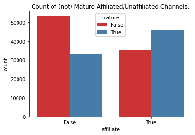

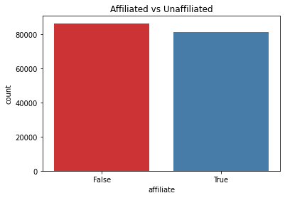

Es hat überraschend viele gepartnete User mit Twitch. Ich hätte nicht gedacht, dass das Verhältnis fast 50/50 ist. Dies lässt sich dadurch erklären, dass wir nicht ein gesamtes Bild von Twitch im Datensatz anschauen, sondern nur einen Bruchteil.

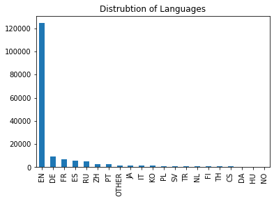

Überwiegend ist die Channelsprache Englisch, gefolgt (weit abgeschlagen) von Deutsch, Französisch, Spanisch und Russisch.

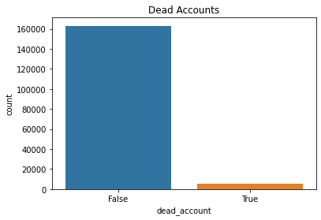

Interessant zu sehen, dass es nur sehr wenige, inaktive User gibt.

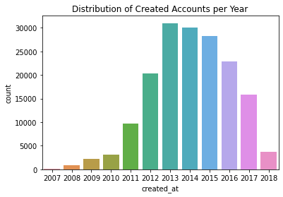

In diesem Plot sieht man deutlich die Jahre, wo Twitch stark zugelegt hat (2011-2016).

Im vorherigen Abschnitt haben wir die Annahme getroffen, dass Twitch-Partner mehr Kanten haben als nicht-Partner. Wir können uns dafür die `Density` von den zwei Subgruppen anschauen.

```
Density von Nicht-Partnern: 0.0006154880996428399
```

```
Density von Partnern: 0.0004175468251946277
```

Das war nicht erwartet; Die Density von nicht-Partnern ist ca. 50% höher als von Partnern. Dies bedeutet, dass sich nicht-Partnern gegenseitiger häufiger folgen als Partner. Ändern sich diese Zahlen, wenn wir inaktive Accounts herausnehmen?

```
Density von aktiven Nicht-Partnern: 0.0006735701234769484
```

```
Density von aktiven Partnern: 0.00041792783234412354
```

Die Density nimmt zu, bei beiden, aber mehr bei den nicht-Partnern. Ergibt auch Sinn, da Partner wohl im Prinzip nicht inaktiv sein können. Dies lässt sich leicht überprüfen in einer Grafik:

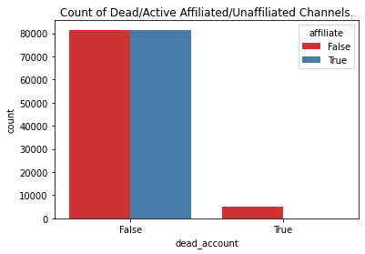

Man sieht aber deutlich, dass die Anzahl von gepartnerten Accounts, welche inaktiv sind, verschwindend gering ist. Das sieht aber fast nach einem Fehler aus. Wie kann die Ratio von geparterten Usern von aktiven Accounts fast identisch sein? Ist da was falsch?

```
Anteil Partner von inaktiven vs. aktiven User:
dead_account  affiliate
False         False        81483
              True         81472
True          False         5085
              True            74
Name: affiliate, dtype: int64
```

Nein, die zwei Zahlen sind fast identisch. Es ist aber trotzdem unerwartet, dass sich nicht-Partner gegenseitig häufiger folgen als Partner.

#### Views

Wir schauen uns nun das Attribut `views` an von aktiven Accounts, separat für Partner und nicht-Partner.

```
Mean views of active accounts without partner: 364752.97
Mean views of active accounts with partner: 23299.74
Median views of active accounts without partner: 1945.00
Median views of active accounts with partner: 7469.00
```

Sehr interessant! Wieder unerwartet. Im Durchschnitt hat ein nicht-Partner ca. 15x mehr Views als Partner. Wenn wir uns aber den Median anschauen, ist das Bild anders; hier hat ein Partner ca. 4x so viele Views. Es scheint so, als hätten nicht-Partner massive Ausreisser in den Views. Dies können wir mit einem Boxplot bestätigen:

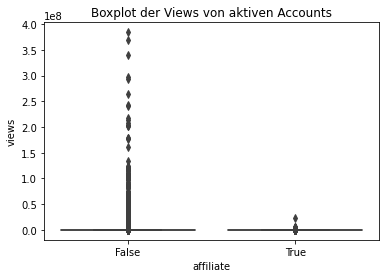

Wir können uns noch die Top 30 anschauen und sehen, dass von den Top 30 Views niemand gepartnert ist mit Twitch.

|  | views | mature | life_time | created_at | updated_at | numeric_id | dead_account | language | affiliate |
| --- | --- | --- | --- | --- | --- | --- | --- | --- | --- |
| 96473 | 384396587 | False | 2416 | 2012-03-01 | 2018-10-12 | 96473 | False | RU | False |
| 129896 | 368912220 | False | 2379 | 2012-04-07 | 2018-10-12 | 129896 | False | EN | False |
| 61862 | 340602050 | False | 2826 | 2011-01-16 | 2018-10-12 | 61862 | False | EN | False |
| 128864 | 297117159 | False | 2314 | 2012-06-11 | 2018-10-12 | 128864 | False | EN | False |
| 144643 | 294116493 | False | 2577 | 2011-09-22 | 2018-10-12 | 144643 | False | EN | False |
| 110345 | 264643346 | False | 2664 | 2011-06-27 | 2018-10-12 | 110345 | False | EN | False |
| 125642 | 243451177 | False | 2507 | 2011-12-01 | 2018-10-12 | 125642 | False | EN | False |
| 64605 | 240718261 | True | 2516 | 2011-11-22 | 2018-10-12 | 64605 | False | EN | False |
| 71050 | 218559516 | False | 2169 | 2012-11-03 | 2018-10-12 | 71050 | False | EN | False |
| 161362 | 213931993 | False | 2359 | 2012-04-27 | 2018-10-12 | 161362 | False | EN | False |
| 52703 | 206941623 | False | 4161 | 2007-05-22 | 2018-10-12 | 52703 | False | EN | False |
| 26309 | 203471447 | False | 2371 | 2012-04-15 | 2018-10-12 | 26309 | False | EN | False |
| 158403 | 202252218 | False | 2359 | 2012-04-27 | 2018-10-12 | 158403 | False | EN | False |
| 32338 | 202142952 | False | 2702 | 2011-05-20 | 2018-10-12 | 32338 | False | EN | False |
| 125828 | 179513429 | False | 2422 | 2012-02-24 | 2018-10-12 | 125828 | False | ZH | False |
| 152394 | 178500544 | False | 2443 | 2012-02-03 | 2018-10-12 | 152394 | False | EN | False |
| 2050 | 177293299 | False | 1987 | 2013-05-04 | 2018-10-12 | 2050 | False | ZH | False |
| 63518 | 160422474 | False | 2305 | 2012-06-20 | 2018-10-12 | 63518 | False | EN | False |
| 39372 | 133196253 | True | 2440 | 2012-02-06 | 2018-10-12 | 39372 | False | EN | False |
| 52552 | 123729653 | False | 2196 | 2012-10-07 | 2018-10-12 | 52552 | False | PL | False |
| 31982 | 121384763 | False | 1030 | 2015-12-17 | 2018-10-12 | 31982 | False | EN | False |
| 40868 | 120307739 | True | 2787 | 2011-02-24 | 2018-10-12 | 40868 | False | EN | False |
| 70350 | 117655872 | True | 2319 | 2012-06-06 | 2018-10-12 | 70350 | False | RU | False |
| 128589 | 116392808 | False | 1896 | 2013-08-03 | 2018-10-12 | 128589 | False | PT | False |
| 58493 | 115083137 | False | 2993 | 2010-08-02 | 2018-10-12 | 58493 | False | EN | False |
| 73213 | 110913108 | True | 3452 | 2009-04-30 | 2018-10-12 | 73213 | False | EN | False |
| 59951 | 110131156 | False | 2356 | 2012-04-30 | 2018-10-12 | 59951 | False | EN | False |
| 56294 | 108432615 | False | 1479 | 2014-09-24 | 2018-10-12 | 56294 | False | FR | False |
| 123018 | 108115325 | False | 584 | 2017-03-07 | 2018-10-12 | 123018 | False | EN | False |
| 88518 | 105836759 | False | 2279 | 2012-07-16 | 2018-10-12 | 88518 | False | EN | False |

Eine gute Erklärung habe ich dafür nicht, es wäre aber möglich, über das Datum der Usererstellung ein Mapping zu machen zwischen der uniquen ID und dem richtigen Namen und dann mehr herausfinden zu können, warum die Channels mit den meisten User von nicht-Partnern sind.

Beispiel [Tyler1](https://twitchtracker.com/loltyler1):

- Tyler1 hat seinen User am 14.11.2013 erstellt.
- Er spricht Englisch.
- Er hatte Ende 2018 mehr als 80 Millionen Views.

Wir können nun nach diesem User filtern:

|  | views | mature | life_time | created_at | updated_at | numeric_id | dead_account | language | affiliate |
| --- | --- | --- | --- | --- | --- | --- | --- | --- | --- |
| 6250 | 84804681 | True | 1793 | 2013-11-14 | 2018-10-12 | 6250 | False | EN | False |

Somit entspricht die `numeric_id` 6250 wohl Tyler1. Gewisse Sachen haben sich aber geändert: Jetzt ist der Channel von Tyler1 nicht mehr an Erwachsene gerichtet. Ebenfalls war er Ende 2018 nicht Partner. Ich kann mich aber erinnern, dass Tyler1 [gebannt](https://web.archive.org/web/20190417084311/https://support.riotgames.com/hc/en-us/articles/115013815928-Understanding-ID-Bans) wurde in diesem Zeitrahmen (~2017/18) und danach wurde sein Account wieder freigeschaltet, hat aber wahrscheinlich seinen Partner-Status verloren.

Warum die meistgesehenen Channels aber nicht gepartnert sind, bleibt eine offene Frage.

#### 0 ist 1 und 1 ist 0 beim Attribut `Affiliated`?

Hier lässt sich aber auch die Annahme treffen, dass in den Daten ein Fehler passiert ist und beim Knotenatttribut `affiliated` 1 und 0 verwechselt wurde. Es ist sehr unwahrscheinlich, dass keiner der Top 30 meistgesehenen User mit Twitch gepartnert ist. Ggf. muss man also gewisse Analysen im EDA-Teil weiter oben anders interpretieren. Die Daten sind von 2018, aber momentan ist `Ninja` und `Tyler1` gepartnert mit Twitch. Somit lässt sich diese Annahme bestätigen, dass `affiliated` falsch herum gelabelt wurde.

Falls wir also mehr mit dem Attribut `affiliated` machen würden, müssten wir uns fragen, ob diese Daten für das geeignet sind oder uns 100 % sicher sein, dass das Attribut `affiliated` auch wirklich so stimmt. Die Daten könnten wir theoretisch auch selber von [TwitchTracker](https://twitchtracker.com/) crawlen.

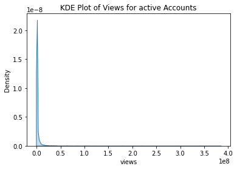

```
Percentiles of views:
0.25       1515.00
0.50       4336.00
0.75      14848.50
0.99    2676764.08
Name: views, dtype: float64
```

Wir sehen, dass die meiste Density von Views in einem `KDEPlot` für alle aktiven Accounts in einem sehr kleinen Bereich liegt. 25 % der User haben weniger als `1515` Views auf ihrem Channel und 50 % weniger als `4336`. Wir sehen auch, dass wir gegen oben (>99 Perzentil) es unglaubliche Ausreisser gibt, welche unseren Density Plot verziehen.

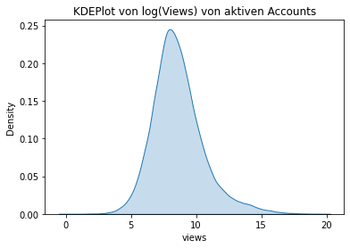

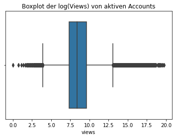

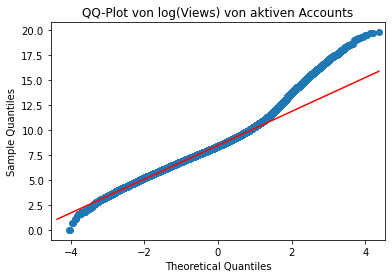

Die Verteilung der Views scheint eine Lognorm-Verteilung zu sein, mit massiven Ausreissern gegen oben hin (long-tail gegen rechts). Dies sehen wir daran, dass die Verteilung nach einer Normalverteilung aussieht, wenn wir den `log` der Daten nehmen.

### Degree Centrality

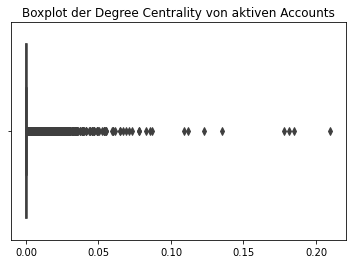

```
Percentiles of Degrees:
        degree
0.25  0.000077
0.50  0.000190
0.75  0.000446
0.90  0.000964
```

```
[('61862', 0.2098528965636209)]
```

Wir können schauen, wer das sein könnte.

|  | views | mature | life_time | created_at | updated_at | numeric_id | dead_account | language | affiliate |
| --- | --- | --- | --- | --- | --- | --- | --- | --- | --- |
| 61862 | 340602050 | False | 2826 | 2011-01-16 | 2018-10-12 | 61862 | False | EN | False |

[Ninja](https://twitchtracker.com/ninja) hat seinen Account am 16.1.2011 erstellt und er ist einer der meistgeschauten Streamer auf Twitch. Man kann also annehmen, dass er `61862` ist.

```
Node: 61862, Degree: 0.2098528965636209
Number of neighbors: 35279
```

Dies ist schon erstaunlich. Kann dies wirklich sein, dass Ninja 20% der User auf Twitch folgt (35279 User)? Vielleicht bedeutet `mutual relationship` etwas anderes?

Zitat aus dem Paper von Twitch Gamers:

```
Mutual relationships. We discarded relationships which
are asymmetric and only included mutual edges in the re-
leased dataset.
```

Ich bin mir unsicher. Es kann ja nicht sein, dass `Ninja` 20% der User auf Twitch folgt.

Andererseits schauen wir uns in diesem Datensatz ja nicht ganz Twitch an, sondern nur ein Subset. Auf [TwitchTracker](https://twitchtracker.com/statistics) sehen wir, dass es in 2018 im Schnitt 1.08 Millionen Zuschauer gab. Somit schauen wir uns mit 168'114 Knoten auch nur einen kleinen Bruchteil von Twitch an.

Somit haben wir in unserem Datensatz nur User mit:

- mindestens einer Kante (gegenseitiges folgen).
- sind vom User `lowko` über ein Schneeball-System erreichbar.

Es kann also wirklich sein, dass `Ninja` 20% von diesem Subset folgt.

### Degrees

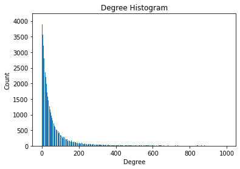

Die Verteilung der Anzahl der Degrees sieht sehr exponential aus.

### Korrelation Degree und Views

Hat ein User mit vielen Kanten mehr Views?

|  | numeric_id | degree |
| --- | --- | --- |
| 0 | 98343 | 39 |
| 1 | 141493 | 4456 |
| 2 | 58736 | 420 |
| 3 | 140703 | 242 |
| 4 | 151401 | 235 |

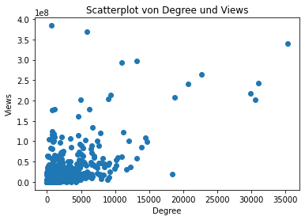

```
Pearson Korrelation von degree und views: 0.650
```

```
Spearman Korrelation von degree und views: 0.514
```

Wieder etwas interessantes gelernt. Laut [StackExchange](https://stats.stackexchange.com/questions/27127/what-does-it-indicate-when-the-spearman-correlation-is-a-definite-amount-less-th) ist die Spearman Korrelation niedriger als die Pearson Korrelation, falls die Rank-Korrelation niedriger ist als die Lineare-Korrelation. Das kann passieren, falls es extreme Ausreisser gibt / einen langen Longtail. Dies ist bei uns der Fall.

#### Permutationstest

Mit einem Permutationstest können wir schauen, ob diese Pearson Korrelation nur Zufall ist. Wir wählen als `alpha` 0.05. Unsere Nullhypothese ist, dass der `degree` und die Anzahl Views nicht linear miteinander korrelieren. Die Alternativhypothese ist, dass sie miteinander korrelieren.

```
p-Wert von Pearson: 0.0
```

Da der p-Wert kleiner ist als unser `alpha`, verwerfen wir die Nullhypothese und schätzen die Korrelation zwischen Knoten-Degree und Anzahl Views als signifikant ein.

## Reichweite maximieren, Kosten minimieren

Für eine fiktive Werbung möchten wir ein möglichst weites Publikum für möglichst kleines Geld erreichen. Es lässt sich die Annahme treffen, dass neue Streamer mit eher wenig Degrees günstiger zu kaufen sind (sind nicht "etabliert", z.B. Freunde von grossen Streamer, welche gerade angefangen haben zu Streamen, erreichen viele Views, haben aber wenig followers) und das Streamer mit vielen Views eine grosse Reichweite haben.

Somit sollten wir folgendes optimieren:

- Degrees minimieren mit Hilfe von Knoten, welche keine oder nur wenig, gleiche Nachbarn haben, damit keine Überlappung der Views entsteht (e.g. verhindern, dass unsere Werbung von zwei gleichen Usern mehrmals gesehen wird)
- Totale Anzahl Views maximieren.

Da die lineare Korrelation mit 0.650 nicht perfekt ist, können wir einen Algorithmus dafür entwickeln, welche diese Relation optimiert.

Wir nehmen an, dass die Anzahl Degrees perfekt linear korreliert mit dem verlangtem Geld vom Streamer für das zeigen unserer Werbung. Somit erstellen wir eine Ratio `views per year/degree` und wollen diese möglichst hoch halten. Ebenfalls möchten wir keine Verträge mit tausenden von Streamer abschliessen und definieren eine Mindest-Anzahl `views per year`, basierend auf der maximalen Anzahl Verträge (`MAX_VERTRÄGE`), welche wir erstellen möchten.

### Annahmen

Da wir keine `views per year` haben, teilen wir einfach die Anzahl Views durch die Anzahl Jahre seit ihrer Regristierung. Wir nehmen auch an, dass im nächsten Jahr (2019, da die Daten nur bis 2018 gehen) die Streamer genau `views per year` erreichen werden. Das entspricht nicht der Realität, aber wir haben keine besseren Daten. Ebenfalls sind wir auf den deutschen und englischen Markt fokusiert.

|  | views | mature | life_time | created_at | updated_at | numeric_id | dead_account | language | affiliate | degree | registration_year | views_per_year | views_per_year_per_degree |
| --- | --- | --- | --- | --- | --- | --- | --- | --- | --- | --- | --- | --- | --- |
| 0 | 7879 | True | 969 | 2016-02-16 | 2018-10-12 | 0 | False | EN | True | 43 | 2016 | 2626.333333 | 61.077519 |
| 1 | 500 | False | 2699 | 2011-05-19 | 2018-10-08 | 1 | False | EN | False | 278 | 2011 | 62.500000 | 0.224820 |
| 2 | 382502 | True | 3149 | 2010-02-27 | 2018-10-12 | 2 | False | EN | True | 122 | 2010 | 42500.222222 | 348.362477 |
| 3 | 386 | False | 1344 | 2015-01-26 | 2018-10-01 | 3 | False | EN | False | 11 | 2015 | 96.500000 | 8.772727 |
| 4 | 2486 | False | 1784 | 2013-11-22 | 2018-10-11 | 4 | False | EN | False | 33 | 2013 | 414.333333 | 12.555556 |

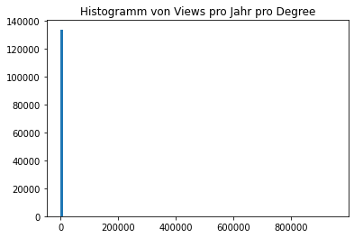

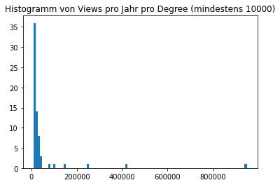

Im Histogram sehen wir, dass das Attribut `views_per_year_per_degree` einen Longtail gegen Rechts hat und viele Werte sind um 0 herum.

### Algorithmus

```
Copying features and Graph
Starting optimization
```

```
['53061',
 '30442',
 '65149',
 '78188',
 '158894',
 '111659',
 '150207',
 '101367',
 '75091']
```

Das sind unsere "High-Impact Users" (hiu), welche wahrscheinlich auch noch günstig sind.

|  | views | mature | life_time | created_at | updated_at | numeric_id | dead_account | language | affiliate | degree |
| --- | --- | --- | --- | --- | --- | --- | --- | --- | --- | --- |
| 30442 | 16817348 | False | 1635 | 2014-04-21 | 2018-10-12 | 30442 | False | EN | False | 8 |
| 53061 | 23756568 | False | 1731 | 2014-01-15 | 2018-10-12 | 53061 | False | EN | True | 5 |
| 65149 | 4324523 | False | 549 | 2017-04-11 | 2018-10-12 | 65149 | False | EN | False | 21 |
| 75091 | 100394785 | False | 2065 | 2013-02-15 | 2018-10-12 | 75091 | False | DE | False | 1052 |
| 78188 | 36165622 | False | 2636 | 2011-07-25 | 2018-10-12 | 78188 | False | EN | False | 135 |
| 101367 | 39945429 | False | 2788 | 2011-02-23 | 2018-10-12 | 101367 | False | EN | False | 325 |
| 111659 | 26643418 | False | 2716 | 2011-05-06 | 2018-10-12 | 111659 | False | EN | False | 151 |
| 150207 | 99120396 | False | 2094 | 2013-01-17 | 2018-10-12 | 150207 | False | EN | False | 923 |
| 158894 | 9083205 | False | 1597 | 2014-05-29 | 2018-10-12 | 158894 | False | DE | False | 76 |

```
Pearson Correlation von degree und views: 0.975
```

Das scheint zu passen! Wir sehen, dass die Degrees stark mit der Anzahl Views steigen. Wir "akzeptieren" also nur viele Degrees, falls dafür auch viele Views kommen. Wir sehen das auch an der hohen Pearson Korrelation von 0.975.

```
Mean views per year per degree of all users: 126.32
```

```
Mean views per year per degree of high impact users: 178030.46
```

Unser Algorithmus macht also das, was wir wollen: `views per year` / `degree` maximieren. Wir sehen das daran, dass unsere ratio sehr stark über dem Durchschnitt ist. Somit erreichen wir sehr viele Views mit Hilfe von nicht-etablierten Streamern und können ggf. sogar mit ihnen "zur Spitze von Twitch" reiten.

```
Group degree centrality of high impact users 0.015
```

```
Predicted views in 2019: 58190524
```

Wir sehen also, dass wir mit den High Impact Users eine gute Anzahl an Views in 2019 erreichen mit Streamer, welche nicht etabliert sind (gemessen an der Anzahl follower). Wir erreichen also viele Views mit nicht-etablierten Views.

## High-Degree User

Wir möchten gerne viele User im deutschen Raum erreichen mit möglichst wenig Usern.

### Ansatz

Wir möchten gerne eine gewisse Anzahl User beeinflussen und diese dazu bringen, unser Produkt zu vermarkten. Diese Vermarktung soll auch weitergeleitet werden. Unser Produkt soll also via "Mund-zu-Mund-Werbung" vermarktet werden (unsere `angestellten` User beeinflussen persönlich andere User, mit welche sie eine Kante haben). Wir möchten also User finden, welche eine hohen `degree` haben. Wir möchten aber keine "überlappenden" Nachbarn haben um unsere Reichweite zu maximieren.

##### Connected Components

```
Graph DE is nicht verbunden. Es hat 187 Komponenten.
```

Der deutsche Teil vom Netzwerk ist also nicht komplett verbunden; Es hat also `subgraphen`, welche man nicht von überall erreichen kann. Somit hat es viele User mit einer `degree` von 0.

```
(array([   1,    2, 9240]), array([184,   2,   1], dtype=int64))
```

#### Algorithmus

Unser Algorithmus soll die `group_degree_centrality` maximieren mit einer gewissen Anzahl user, damit wir wenig Verträge abschliessen müssen (`MAX_VERTRÄGE`). Ebenfalls sollen diese Gruppe wenig Überlappung haben, damit wir viele verschiedene User beeinflussen können. Wir wollen aber nicht viele Verträge abschliessen, definieren also eine Variable, welche diese begrenzt.

Somit wollen wir mit einer bestimten Anzahl User die `group_degree_centrality` maximieren.

```
Copying Graph
Starting optimization
```

```
Group Degree Centrality of high degree centrality users: 0.60
```

Wir erreichen also 60% der deutschen User mit unseren 8 Leuten.

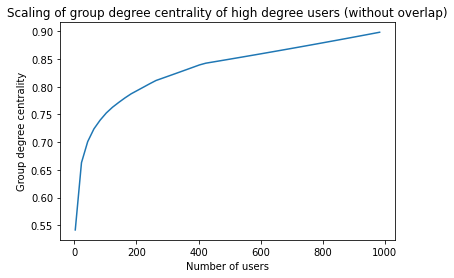

In der oberen Grafik sehen wir, dass unsere nicht-überlappende `group-degree-centrality` von unseren ausgewählten User mit einer grösseren Anzahl von Usern zunimmt. Leider nimmt diese weniger stark zu, desto grösser die Gruppe schon ist. Am Anfang sehen wir eine starke zunahme, bis ca. 100 Usern. Damit nimmt diese stark ab. Diese Abnahme können wir auch genauer anschauen:

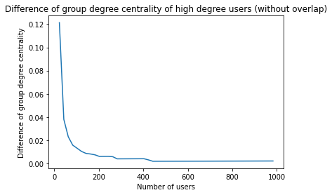

Wir können durch eine Subtraktion ein theoretisches Optimum herausfinden, basierend auf der stärke Zunahme der `group degree centrality` mit neuen Usern. Natürlich sollten wir uns eher auf eine Reichweite festlegen, aber das gibt schonmal guten Input. Die Abnahme ist beim Unterschreiten von ca. 0.02 der Subtraktion viel schwächer.

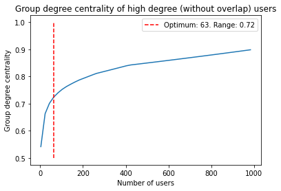

Somit wäre eine Anzahl von 63 Usern ein guter, effizienter Wert um die Reichweite zu maximieren, welcher 72% vom deutschen Raum erreichen würde.

#### High Impact User

Wer sind diese High Impact User?

```
Copying Graph
Starting optimization
```

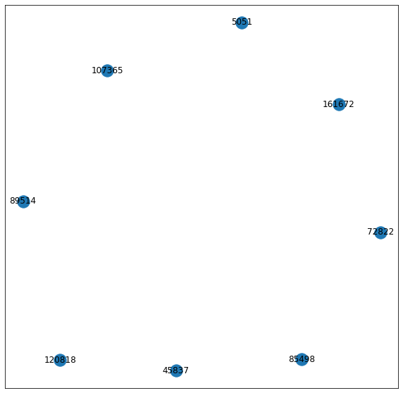

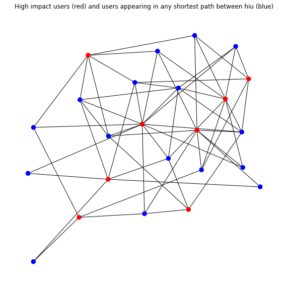

Rot sind unsere `high impact user` und blaue user, welche in irgendeiner kürzesten Distanz zwischen zwei `high impact usern` vorkommen.

```
Durchschnittliche Distanz zwischen den high impact user: 1.56
```

Wir sehen also, dass im Durchschnitt zwischen zwei (shortest path) `high impact user` 1.56 Nodes sind. Es ist interessant, wie nahe diese hiu zueinander sind.

## Community Detection

### Community Detection mit Louvain's Algorithmus

```
(array([   1,    2,  652,  866,  916, 1135, 1314, 1378, 1428, 1551]),
 array([184,   2,   1,   1,   1,   1,   1,   1,   1,   1], dtype=int64))
```

Die obere Zeile entspricht der Grösse der Community (Anzahl User per Community) und die untere der Anzahl der Communities mit dieser Grösse. Wir sehen beim oberen Output, dass wir hier wieder die 184 nicht-verbundenen Subgraphen sehen, welche nur aus sich selbst bestehen. Diese bilden dann logischerweise nur alleine eine Community. Wir können schauen, ob unsere vorhin gefundene Gruppe von Usern mit einer hohen `group degree centrality`, zusammen in einer Community auftauchen.

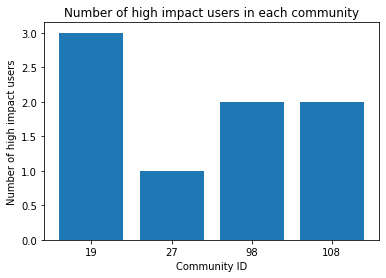

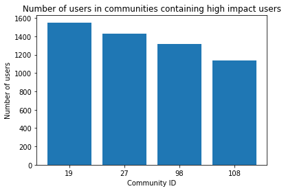

Im oberen Plot sehen wir die unterschiedlichen Grössen der Communities.

```
19
```

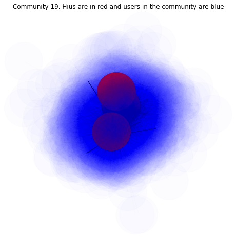

[figure not shown]

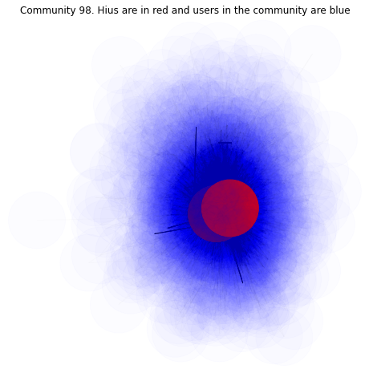

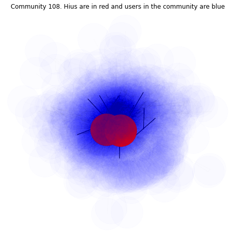

Hier wurden die Communities geplottet. Rot sind unsere `hiu`s und blau normale User, welche nur mit einer sehr hohen transparenz angezeigt werden.

Wir sehen, dass unsere `hiu`s (rot) in allen Communities in der Mitte sind, wenn wir den Graphen mit dem `spring-layout` plotten. Sie sind also `physikalisch` immer in der Mitte des geschehens. Natürlich können wir das bestätigen mit der `degree` und der `betweenness centrality`, dass unsere `hiu`s in der Community sehr zentral sind.

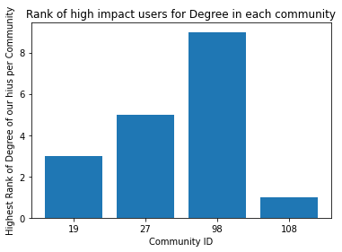

Wir sehen im oberen Plot pro Community den besten, erreichten Rang von irgendeinem unserer `hiu` per Community. Wie erwartet erreichen unsere `hiu`s in jeder Community einen hohen Degree-Stellenwert. Interessant ist aber, dass wir in der Community `98` nur den 9ten Platz erreichen. Hier wäre es interessant zu suchen, warum dies der Fall ist.

Wie sieht es aber mit der `betweenness-cetrality` aus?

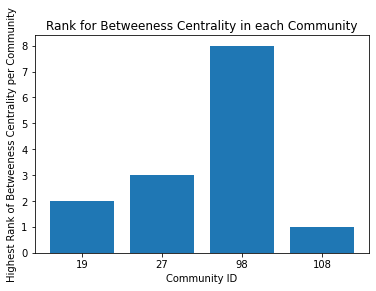

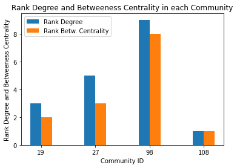

## Ausblick

### Analysen

Bei der `community-detection` haben wir etwas unewartetes getroffen; warum sind unsere `hiu`s nicht am zentralsten aufgestellt? Das zu beantworten würde uns versichern, dass unser Algorithmus wie erwartet funktioniert.

### Weitere Märtke

Unsere Analysen lassen sich auch auf den englischen Raum übertragen. Wir könnten also auch weitere Märkte sehr gut ins Auge fassen.

### Zeitliche Daten

Falls wir uns auf Twitch fokusieren würden, könnten wir damit anfangen, die Daten zeitlich zu erfassen. Dies beduetet, z.B. wöchentlich einen digitalen Abdruck von Twitch abspeichern. Damit liesse sich noch besser `hiu`s finden. Man könnte Aufsteiger abfangen und als günstigen Influencer anwerben, falls man den Algorithmus `maximize_views_per_year_per_degree_without_overlap` auf die Views von den z.B. vergangenen 4 Wochen beschränken würde. Damit liessen sich Aufsteiger entdecken, welche aber noch nicht so etabliert sind. Man könnte einen Web-Crawler für [TwitchTracker](https://twitchtracker.com/statistics) und dies wöchentlich "crawlen" und hätte dann Daten für eine tolle Ausgangslage.

### Verbreitung von Informationen

Eine weitere Idee wäre das verbreiten von Informationen. Wir könnten uns auch anschauen, wie Podcast-Streamer informationen verbreiten, z.B. mit einem `Independent-Cascade-Model`. Wir könnten da als `p` die Aktivität des Podcasters nehmen (#StundenStreamingProWoche / #StundenInDerWoche) und so Podcaster finden, welche unsere Informationen verbreiten könnten.

### Twitch-Payouts

Es gab letztens auch einen [Leak über die Twitch-Payouts](https://dotesports.com/streaming/news/full-list-of-all-twitch-payouts-twitch-leaks). Das wäre natürlich ein sehr interessantes, neues Features und man könnte damit die `Degrees` aus dem Algorithmus `maximize_views_per_year_per_degree_without_overlap` ersetzen, damit unsere Daten mehr der Realität entspricht, da die `Degrees` wohl nicht perfekt mit den Einnahmen von Streamer übereinstimmen.

##### html creation

Creates the two HTML.

```
[NbConvertApp] Converting notebook main.ipynb to html
[NbConvertApp] Writing 1787290 bytes to main_no_code.html
```

```
[NbConvertApp] Converting notebook main.ipynb to html
[NbConvertApp] Writing 1945794 bytes to main_code.html
```